# JSE Dataset Cleaning

Murema Manganyi

2025-07-21

### Setup

Load all necessary packages. tidyverse for data wrangling, lubridate for dates, zoo/slider for rolling calculations, naniar to aid missingness understanding, and DT for interactive tabular inspection.

```r
library(tidyverse)
library(lubridate)
library(zoo)
library(ggplot2)
library(DT)
library(naniar)
library(knitr)
library(slider)
```

### Load and Explore the Raw Data

Reads the raw CSV and inspect its tail/head to confirm it loaded as expected.

```r
jse_data <- read_csv("input/ohlc_metrics.csv")
tail(jse_data) %>%
  DT::datatable()
```

|  | Date | dayOfWeek | Ticker | Open | High | Low | Close | Volume | MA_20 | MA_50 | Volatility_30D | Volatility_60D | Daily_Return | VWAP_7D |
| --- | --- | --- | --- | --- | --- | --- | --- | --- | --- | --- | --- | --- | --- | --- |
| 1 | 2025-05-23 | 4 | WHLJ.J | 5543 | 5741 | 5543 | 5731 | 1218886 | 5702.95 | 5474.66 | 0.018763032 | 0.019829045 | 0.014695467 | 5702.866928 |
| 2 | 2025-05-26 | 0 | WHLJ.J | 5750 | 5775 | 5649 | 5730 | 1212483 | 5705.15 | 5479.68 | 0.017690769 | 0.019823666 | -0.00017449 | 5692.212315 |
| 3 | 2025-05-27 | 1 | WHLJ.J | 5675 | 5777 | 5659 | 5680 | 2087765 | 5704.85 | 5484.28 | 0.017403986 | 0.019383953 | -0.008726003 | 5684.600414 |
| 4 | 2025-05-28 | 2 | WHLJ.J | 5500 | 5771 | 5500 | 5765 | 1414257 | 5708.05 | 5492.16 | 0.017159455 | 0.019472401 | 0.014964789 | 5683.791366 |
| 5 | 2025-05-29 | 3 | WHLJ.J | 5601 | 5869 | 5601 | 5858 | 2313723 | 5712.95 | 5503 | 0.017098873 | 0.019585488 | 0.01613183 | 5713.594186 |
| 6 | 2025-05-30 | 4 | WHLJ.J | 5860 | 5916 | 5802 | 5860 | 8665624 | 5713.9 | 5512.54 | 0.011446036 | 0.019493665 | 0.000341413 | 5795.279794 |

### Checking for duplicates

Ensuring uniqueness of each observation by checking Ticker + Date. Duplicates can distort aggregated features or bias models.

```r
# Check for duplicates based on Ticker + Date
dup_count <- jse_data %>%
  count(Ticker, Date) %>%
  filter(n > 1)
print(dup_count)
```

```
## # A tibble: 0 × 3
## # ℹ 3 variables: Ticker <chr>, Date <date>, n <int>
```

### Missing value check

Most important part of data cleaning, and most sensitive for ML models. Count missing values globally and by ticker. This shows where the dataset has gaps and informs the imputation strategy

```r
# Show count of missing values per column
colSums(is.na(jse_data))
```

```
##           Date      dayOfWeek         Ticker           Open           High
##              0              0              0             79             74
##            Low          Close         Volume          MA_20          MA_50
##             74             31             73           1132           2588
## Volatility_30D Volatility_60D   Daily_Return        VWAP_7D
##           1692           3086             98              0
```

### Missing Values Overview

```r
# Count NAs by Ticker and Column
jse_data %>%
  group_by(Ticker) %>%
  summarise(across(where(is.numeric), ~sum(is.na(.)))) %>%
  arrange(desc(Close)) %>%
  DT::datatable()
```

|  | Ticker | dayOfWeek | Open | High | Low | Close | Volume | MA_20 | MA_50 | Volatility_30D | Volatility_60D | Daily_Return | VWAP_7D |
| --- | --- | --- | --- | --- | --- | --- | --- | --- | --- | --- | --- | --- | --- |
| 1 | ABGJ.J | 0 | 24 | 24 | 24 | 24 | 24 | 313 | 564 | 428 | 622 | 46 | 0 |
| 2 | ANGJ.J | 0 | 8 | 7 | 7 | 7 | 7 | 97 | 162 | 124 | 184 | 14 | 0 |
| 3 | AGLJ.J | 0 | 1 | 1 | 1 | 0 | 1 | 19 | 49 | 30 | 60 | 1 | 0 |
| 4 | ANHJ.J | 0 | 1 | 0 | 0 | 0 | 0 | 19 | 49 | 30 | 60 | 1 | 0 |
| 5 | APNJ.J | 0 | 1 | 1 | 1 | 0 | 1 | 19 | 49 | 30 | 60 | 1 | 0 |
| 6 | BHGJ.J | 0 | 0 | 0 | 0 | 0 | 0 | 19 | 49 | 30 | 60 | 1 | 0 |
| 7 | BIDJ.J | 0 | 0 | 0 | 0 | 0 | 0 | 19 | 49 | 30 | 60 | 1 | 0 |
| 8 | BTIJ.J | 0 | 0 | 0 | 0 | 0 | 0 | 19 | 49 | 30 | 60 | 1 | 0 |
| 9 | BVTJ.J | 0 | 0 | 0 | 0 | 0 | 0 | 19 | 49 | 30 | 60 | 1 | 0 |
| 10 | CLSJ.J | 0 | 2 | 2 | 2 | 0 | 2 | 19 | 49 | 30 | 60 | 1 | 0 |

[output cut: 30 more lines]

## Impute Missing OHLCV Values (Forward Fill)

Forward-fill missing price and volume fields per ticker

```r
# Sort by Ticker and Date
jse_data_clean <- jse_data %>%
  arrange(Ticker, Date) %>%
  group_by(Ticker) %>%
  mutate(
    Open = zoo::na.locf(Open, na.rm = FALSE),
    High = zoo::na.locf(High, na.rm = FALSE),
    Low = zoo::na.locf(Low, na.rm = FALSE),
    Close = zoo::na.locf(Close, na.rm = FALSE),
    Volume = zoo::na.locf(Volume, na.rm = FALSE)
  ) %>%
  ungroup()
```

We need continuous time series for each stock, many of our indicators like moving averages, daily returns, and volatilities are calculated from past price values. If there are gaps in prices, these features break down or become noisy. Forward filling preserves historical consistency without artificial jumps.

```r
# Count NAs by Ticker and Column
jse_data_clean %>%
  group_by(Ticker) %>%
  summarise(across(where(is.numeric), ~sum(is.na(.)))) %>%
  arrange(desc(Close)) %>%
  DT::datatable()
```

|  | Ticker | dayOfWeek | Open | High | Low | Close | Volume | MA_20 | MA_50 | Volatility_30D | Volatility_60D | Daily_Return | VWAP_7D |
| --- | --- | --- | --- | --- | --- | --- | --- | --- | --- | --- | --- | --- | --- |
| 1 | ABGJ.J | 0 | 0 | 0 | 0 | 0 | 0 | 313 | 564 | 428 | 622 | 46 | 0 |
| 2 | AGLJ.J | 0 | 0 | 0 | 0 | 0 | 0 | 19 | 49 | 30 | 60 | 1 | 0 |
| 3 | ANGJ.J | 0 | 0 | 0 | 0 | 0 | 0 | 97 | 162 | 124 | 184 | 14 | 0 |
| 4 | ANHJ.J | 0 | 0 | 0 | 0 | 0 | 0 | 19 | 49 | 30 | 60 | 1 | 0 |
| 5 | APNJ.J | 0 | 0 | 0 | 0 | 0 | 0 | 19 | 49 | 30 | 60 | 1 | 0 |
| 6 | BHGJ.J | 0 | 0 | 0 | 0 | 0 | 0 | 19 | 49 | 30 | 60 | 1 | 0 |
| 7 | BIDJ.J | 0 | 0 | 0 | 0 | 0 | 0 | 19 | 49 | 30 | 60 | 1 | 0 |
| 8 | BTIJ.J | 0 | 0 | 0 | 0 | 0 | 0 | 19 | 49 | 30 | 60 | 1 | 0 |
| 9 | BVTJ.J | 0 | 0 | 0 | 0 | 0 | 0 | 19 | 49 | 30 | 60 | 1 | 0 |
| 10 | CLSJ.J | 0 | 0 | 0 | 0 | 0 | 0 | 19 | 49 | 30 | 60 | 1 | 0 |

[output cut: 30 more lines]

## Recalculate Indicators After Imputation

After imputation, recompute all dependent features to avoid mixing true and stale/missing data.

```r
library(dplyr)
library(zoo)

jse_data_clean <- jse_data_clean %>%
  mutate(Date = lubridate::mdy(Date)) %>%   # ensure true Date type
  arrange(Ticker, Date) %>%
  group_by(Ticker) %>%
  mutate(
    Daily_VWAP = (High + Low + Close) / 3,
    MA_20 = zoo::rollmean(Close, k = 20, fill = NA, align = "right"),
    MA_50 = zoo::rollmean(Close, k = 50, fill = NA, align = "right"),
    Daily_Return = (Close / lag(Close)) - 1,
    Volatility_30D = rollapply(Daily_Return, width = 30, FUN = sd,
                               fill = NA, align = "right", na.rm = TRUE),
    Volatility_60D = rollapply(Daily_Return, width = 60, FUN = sd,
                               fill = NA, align = "right", na.rm = TRUE),
    TPxVolume = Close * Volume,
    VWAP_7D = rollapply(TPxVolume, width = 7, FUN = sum,
                        fill = NA, align = "right", na.rm = TRUE) /
              rollapply(Volume, width = 7, FUN = sum,
                        fill = NA, align = "right", na.rm = TRUE)
  ) %>%
  select(Ticker, Date, Open, High, Low, Close, Volume, Daily_VWAP,
         MA_20, MA_50, Daily_Return, Volatility_30D, Volatility_60D,
         VWAP_7D, everything(), -TPxVolume) %>%
  ungroup()
```

```r
jse_data_dropped <- jse_data_clean %>%
  filter(!is.na(MA_20), !is.na(MA_50), !is.na(Daily_Return),
         !is.na(Volatility_30D), !is.na(Volatility_60D))
```

### Confirming Missing values fixed

```r
jse_data_dropped %>%
  group_by(Ticker) %>%
  summarise(across(where(is.numeric), ~sum(is.na(.)))) %>%
  arrange(desc(Close)) %>%
  DT::datatable()
```

|  | Ticker | Open | High | Low | Close | Volume | Daily_VWAP | MA_20 | MA_50 | Daily_Return | Volatility_30D | Volatility_60D | VWAP_7D | dayOfWeek |
| --- | --- | --- | --- | --- | --- | --- | --- | --- | --- | --- | --- | --- | --- | --- |
| 1 | ABGJ.J | 0 | 0 | 0 | 0 | 0 | 0 | 0 | 0 | 0 | 0 | 0 | 0 | 0 |
| 2 | AGLJ.J | 0 | 0 | 0 | 0 | 0 | 0 | 0 | 0 | 0 | 0 | 0 | 0 | 0 |
| 3 | ANGJ.J | 0 | 0 | 0 | 0 | 0 | 0 | 0 | 0 | 0 | 0 | 0 | 0 | 0 |
| 4 | ANHJ.J | 0 | 0 | 0 | 0 | 0 | 0 | 0 | 0 | 0 | 0 | 0 | 0 | 0 |
| 5 | APNJ.J | 0 | 0 | 0 | 0 | 0 | 0 | 0 | 0 | 0 | 0 | 0 | 0 | 0 |
| 6 | BHGJ.J | 0 | 0 | 0 | 0 | 0 | 0 | 0 | 0 | 0 | 0 | 0 | 0 | 0 |
| 7 | BIDJ.J | 0 | 0 | 0 | 0 | 0 | 0 | 0 | 0 | 0 | 0 | 0 | 0 | 0 |
| 8 | BTIJ.J | 0 | 0 | 0 | 0 | 0 | 0 | 0 | 0 | 0 | 0 | 0 | 0 | 0 |
| 9 | BVTJ.J | 0 | 0 | 0 | 0 | 0 | 0 | 0 | 0 | 0 | 0 | 0 | 0 | 0 |
| 10 | CLSJ.J | 0 | 0 | 0 | 0 | 0 | 0 | 0 | 0 | 0 | 0 | 0 | 0 | 0 |

[output cut: 30 more lines]

### Per Ticker Summary Stats

```r
jse_data_dropped %>%
  group_by(Ticker) %>%
  summarise(
    Start = min(as.Date(Date)),
    End = max(Date),
    TradingDays = n(),
    AvgVolume = mean(Volume, na.rm = TRUE),
    Avg_Daily_VWAP = mean(Daily_VWAP, na.rm = TRUE),
    AvgClose = mean(Close, na.rm = TRUE),
    Avg_VWAP_7D = mean(VWAP_7D, na.rm = TRUE)
  ) %>%
  arrange(desc(TradingDays)) %>%
  DT::datatable()
```

|  | Ticker | Start | End | TradingDays | AvgVolume | Avg_Daily_VWAP | AvgClose | Avg_VWAP_7D |
| --- | --- | --- | --- | --- | --- | --- | --- | --- |
| 1 | ABGJ.J |  |  | 4962 | 2160235.775493753 | 14111.70997806449 | 14115.09124821806 | 14105.85121932089 |
| 2 | ANGJ.J |  |  | 4944 | 1353651.443529563 | 27317.48635840682 | 27319.35539179814 | 27289.70290800039 |
| 3 | AGLJ.J |  |  | 4939 | 2357000.49303774 | 33600.83502864122 | 33594.36507502693 | 33557.48546688398 |
| 4 | APNJ.J |  |  | 4939 | 1220759.610800026 | 16270.63874061396 | 16270.0244727625 | 16261.21206763044 |
| 5 | CLSJ.J |  |  | 4939 | 974892.782142134 | 13216.08773705878 | 13215.61935614497 | 13191.37123920671 |
| 6 | CPIJ.J |  |  | 4939 | 168675.3242063201 | 78287.97803110164 | 78335.407420016 | 78105.11591928033 |
| 7 | DSYJ.J |  |  | 4939 | 1217077.7366657 | 9307.539909437808 | 9309.337111560235 | 9293.40442435385 |
| 8 | EXXJ.J |  |  | 4939 | 981853.5078493562 | 11276.0671854675 | 11274.96799828184 | 11264.4759899065 |
| 9 | FSRJ.J |  |  | 4939 | 12633441.15367483 | 4063.795924320038 | 4065.212803064183 | 4060.112952100999 |
| 10 | INLJ.J |  |  | 4939 | 952339.1870824053 | 5439.110894710535 | 5442.253518284673 | 5433.944877488276 |

[output cut: 30 more lines]

Persist both the fully cleaned version and the version trimmed for lookback consistency.

```r
write_csv(jse_data_dropped, "output/jse_data_truncated.csv")
write_csv(jse_data_clean, "output/jse_data_clean.csv")
```

## EDA and Verifying Data Correctness

### Date Coverage Consistency

We want to assess how much historical coverage we have for each ticker. This helps us identify tickers that were either listed recently or have thin/irregular trading data, both of which could affect training an ML model.

```r
# Count number of trading days per ticker
trading_days_by_ticker <- jse_data_clean %>%
  group_by(Ticker) %>%
  summarise(
    First_Date = min(Date),
    Last_Date = max(Date),
    Total_Trading_Days = n()
  ) %>%
  arrange(desc(Total_Trading_Days)) %>%
  DT::datatable()
```

Count tickers whose trading span exceeds a threshold (here 18 years) to know which have deep historical coverage for long-term modeling

```r
# Compute span and filter
stocks_15y <- jse_data %>%
  group_by(Ticker) %>%
  summarise(
    start = min(Date),
    end = max(Date),
    span_years = as.numeric(interval(start, end) / years(1))
  ) %>%
  filter(span_years >= 18)

# Count and show which ones qualify
cat("Number of tickers with ≥18 years of data:", nrow(stocks_15y), "\n")
```

```
## Number of tickers with ≥18 years of data: 29
```

### Verification Against External Source

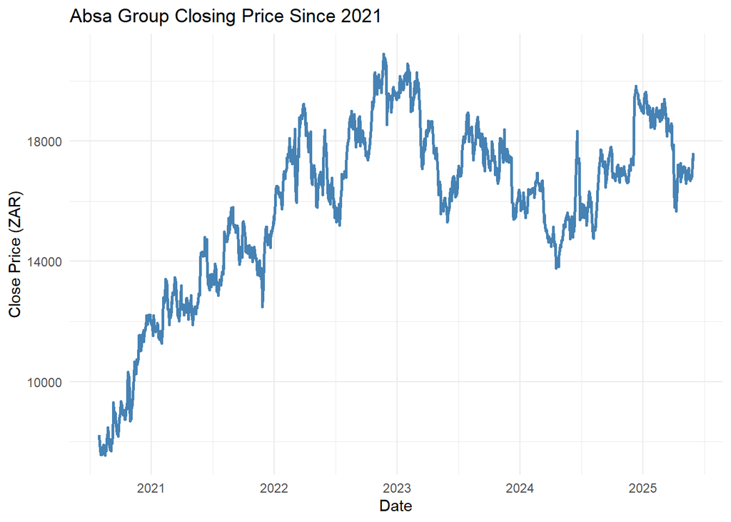

```r
# Filter Absa Group data
absa_data <- jse_data %>%
  filter(Ticker == "ABGJ.J") %>%
  mutate(Date = as.Date(Date)) %>%
  filter(Date >= as.Date("2020-07-30")) %>%
  arrange(Date)

# Plot closing price
ggplot(absa_data, aes(x = Date, y = Close)) +
  geom_line(color = "steelblue", linewidth = 1) +
  labs(
    title = "Absa Group Closing Price Since 2021",
    x = "Date",
    y = "Close Price (ZAR)"
  ) +
  theme_minimal()
```

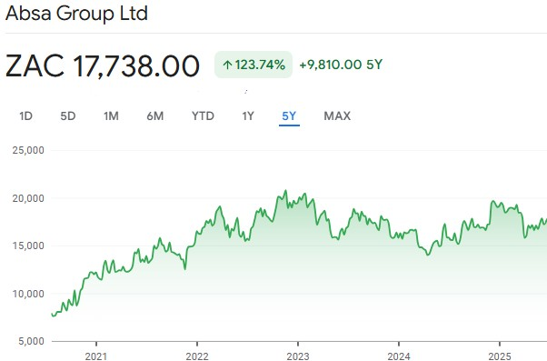

```r
knitr::include_graphics("figures/absa_chart.jpeg")
```

[figure not shown]

```r
# Filter Absa Group data
woolies_data <- jse_data %>%
  filter(Ticker == "WHLJ.J") %>%
  mutate(Date = as.Date(Date)) %>%
  filter(Date >= as.Date("2005-05-30")) %>%
  arrange(Date)

# Plot closing price
ggplot(woolies_data, aes(x = Date, y = Close)) +
  geom_line(color = "steelblue", linewidth = 1) +
  labs(
    title = "Woolworths Closing Price Since 2021",
    x = "Date",
    y = "Close Price (ZAR)"
  ) +
  theme_minimal()
```

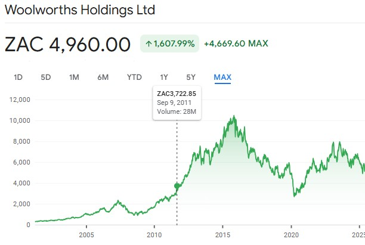

```r
knitr::include_graphics("figures/woolies.jpeg")
```